S2 Statistika Terapan · FMIPA Unpad← Kembali ke Dokumen Kurikulum

Dokumen kurikulum · HTML penuh

# Naskah Akademik Kurikulum 2025 Revisi Tahun 2026

Versi web berbasis teks, tabel, dan gambar HTML asli—bukan PDF yang ditampilkan di dalam iframe.

Buka PDF resmiUnduh PDF

**42 SKS**Beban studi kurikulum revisi

**27 tabel**Disajikan sebagai tabel HTML

**4 gambar**Diagram dokumen asli

**40 halaman**Isi dokumen lengkap

✓

**Konversi HTML penuh.** Seluruh narasi dapat dipilih dan dicari, tabel dirender sebagai elemen HTML, dan diagram ditampilkan sebagai gambar. PDF tetap tersedia sebagai dokumen resmi pembanding.

[figure not shown]

Halaman 2

## LEMBAR PENGESAHAN

### NASKAH AKADEMIK KURIKULUM 2025 REVISI TAHUN 2026 PROGRAM MAGISTER STATISTIKA TERAPAN

Fakultas Matematika dan Ilmu Pengetahuan Alam Universitas Padjadjaran

Naskah Akademik Kurikulum 2025 Revisi Tahun 2026 Program Magister Statistika Terapan Fakultas Matematika dan Ilmu Pengetahuan Alam Universitas Padjadjaran ini disusun sebagai dasar akademik, yuridis, dan operasional bagi penyelarasan beban studi dari 54 SKS menjadi 42 SKS, penguatan proses penelitian tesis, serta integrasi statistika kesehatan dan sains data-kecerdasan artifisial ke dalam pembelajaran berbasis capaian.

Dokumen ini dinyatakan sebagai bahan pengesahan dan acuan implementasi mulai Tahun Akademik 2026/2027 setelah memperoleh persetujuan pada tingkat program studi, departemen, fakultas, dan universitas sesuai kewenangan masing-masing.

Disahkan di : Jatinangor Tanggal : 28 Juli 2026

Disahkan oleh, Ketua Program Studi Magister Statistika Terapan

[figure not shown]

Prof. I Gede Nyoman Mindra Jaya, S.Si., M.Si., Ph.D.

Halaman 3

## KATA PENGANTAR

Puji syukur ke hadirat Tuhan Yang Maha Esa atas rahmat dan karunia-Nya sehingga Naskah Akademik Kurikulum 2025 Revisi Tahun 2026 Program Studi Magister Statistika Terapan FMIPA Universitas Padjadjaran dapat disusun. Naskah ini menjadi dasar pertanggungjawaban akademik atas penyelarasan kurikulum, terutama perubahan beban studi dari 54 SKS menjadi 42 SKS dan penataan kembali tahapan penelitian tesis.

Revisi dilakukan tanpa mengubah daftar mata kuliah yang telah tersedia. Perubahan diarahkan pada efisiensi struktur, penegasan status mata kuliah, pemindahan Seminar Usulan Riset ke semester II, serta penguatan silabus dan asesmen berbasis Outcome-Based Education. Dengan pendekatan tersebut, pengurangan jumlah SKS tidak dimaknai sebagai pengurangan mutu, melainkan sebagai konsolidasi beban belajar agar setiap aktivitas memiliki kontribusi yang jelas terhadap Capaian Pembelajaran Lulusan dan penyelesaian tesis tepat waktu.

Kurikulum ini sekaligus memperjelas kekhasan Program Studi pada statistika kesehatan dan sains data-kecerdasan artifisial. Kekhasan statistika kesehatan dibangun secara proporsional dari ekosistem Universitas Padjadjaran, termasuk keberadaan Fakultas Kedokteran dan rumah sakit pendidikan utama, serta kompetensi yang telah berkembang pada epidemiologi, biostatistika, analisis survival, data longitudinal, pemetaan penyakit, dan statistika spasial-spasiotemporal. Kekhasan sains data dan AI ditempatkan di atas fondasi probabilitas, inferensi, komputasi, validasi, evaluasi ketidakpastian, dan etika; AI digunakan untuk memperkuat analisis dan pengambilan keputusan, bukan menggantikan penalaran statistika.

Penyusunan naskah menggunakan telaah Kurikulum 2025, dokumen revisi 42 SKS, hasil jajak pendapat 31 stakeholder mengenai optimalisasi AI, regulasi resmi, dan studi banding program sejenis di dalam dan luar negeri. Tim Penyusun menyampaikan penghargaan kepada pimpinan universitas dan fakultas, Departemen Statistika, dosen, mahasiswa, alumni, pengguna lulusan, asosiasi profesi, dan mitra yang telah memberikan masukan.

Naskah ini masih memuat sejumlah butir yang memerlukan konfirmasi formal, terutama keputusan rapat fakultas, masa transisi angkatan, konsistensi penempatan SKR, dan harmonisasi tabel jalur RPL/berbasis riset. Butir tersebut dinyatakan secara eksplisit agar proses pengesahan berlangsung transparan dan tidak menghasilkan ketentuan yang melampaui dokumen resmi.

Jatinangor, Juli 2026 Ketua Program Studi Prof. I Gede Nyoman Mindra Jaya, S.Si., M.Si., Ph.D.

Halaman 4

## DAFTAR ISI

KATA PENGANTAR ................................................................................................................ ii

DAFTAR ISI ............................................................................................................................. iii

DAFTAR TABEL ..................................................................................................................... vi

DAFTAR GAMBAR ............................................................................................................... vii

RINGKASAN EKSEKUTIF ................................................................................................... viii

BAB I PENDAHULUAN .......................................................................................................... 1

1.1 Latar Belakang ................................................................................................................. 1

1.2 Tujuan Penyusunan .......................................................................................................... 1

1.3 Ruang Lingkup ................................................................................................................ 1

1.4 Metode Penyusunan ......................................................................................................... 2

1.5 Prinsip Penyusunan .......................................................................................................... 2

BAB II EVALUASI PELAKSANAAN KURIKULUM 2025 .................................................. 3

2.1 Gambaran Struktur Kurikulum 2025 ............................................................................... 3

2.2 Temuan Evaluasi Struktur ............................................................................................... 3

2.3 Masukan Stakeholder tentang Optimalisasi AI ............................................................... 4

2.4 Evaluasi Konsistensi Dokumen ....................................................................................... 4

2.5 Rumusan Masalah Revisi ................................................................................................ 5

BAB III LANDASAN FILOSOFIS, SOSIOLOGIS, YURIDIS, DAN AKADEMIK .............. 5

3.1 Landasan Filosofis ........................................................................................................... 5

3.2 Landasan Sosiologis ........................................................................................................ 5

3.3 Landasan Yuridis ............................................................................................................. 5

3.4 Landasan Akademik dan OBE......................................................................................... 6

3.5 Landasan Penjaminan Mutu dan Akreditasi .................................................................... 6

BAB IV PERKEMBANGAN ILMU STATISTIKA, SAINS DATA, DAN KECERDASAN ARTIFISIAL .............................................................................................................................. 7

4.1 Konvergensi Statistika dan Sains Data ............................................................................ 7

4.2 Peran AI dalam Pendidikan Statistika ............................................................................. 7

4.3 Kompetensi AI yang Relevan pada Jenjang Magister ..................................................... 8

4.4 Responsible AI dan Integritas Akademik ........................................................................ 8

4.5 Implikasi terhadap Silabus ............................................................................................... 8

BAB V KEKHASAN PROGRAM STUDI DALAM STATISTIKA KESEHATAN DAN SAINS DATA-AI ....................................................................................................................... 8

Halaman 5

5.1 Rasional Kekhasan........................................................................................................... 8

5.2 Statistika Kesehatan ......................................................................................................... 9

5.3 Sains Data dan Kecerdasan Artifisial .............................................................................. 9

5.4 Integrasi Dua Pilar ......................................................................................................... 10

5.5 Batas Klaim Kekhasan ................................................................................................... 10

BAB VI HASIL STUDI BANDING NASIONAL DAN INTERNASIONAL ....................... 10

6.1 Metode dan Batas Perbandingan ................................................................................... 10

6.2 Benchmarking Nasional................................................................................................. 11

6.3 Benchmarking Internasional .......................................................................................... 12

6.4 Analisis Posisi Kurikulum Revisi .................................................................................. 13

BAB VII RANCANGAN PERUBAHAN KURIKULUM ...................................................... 13

7.1 Prinsip Rancangan ......................................................................................................... 13

7.2 Rekonsiliasi Perubahan 54 menjadi 42 SKS ................................................................. 14

7.3 Perbandingan Rinci Perubahan ...................................................................................... 14

7.4 Struktur Kurikulum Revisi per Semester ....................................................................... 16

7.5 Dampak terhadap CPL dan Bahan Kajian ..................................................................... 16

7.6 Penyempurnaan Silabus dan Integrasi AI ...................................................................... 17

7.7 Penguatan Mekanisme SUR, SKR, dan SAM ............................................................... 17

7.8 Jalur Berbasis Riset dan RPL ........................................................................................ 18

BAB VIII ANALISIS DAMPAK DAN STRATEGI IMPLEMENTASI ................................ 18

8.1 Dampak terhadap Proses Pembelajaran ......................................................................... 18

8.2 Strategi Implementasi Bertahap ..................................................................................... 19

8.3 Masa Transisi Mahasiswa .............................................................................................. 19

8.4 Risiko Implementasi dan Mitigasi ................................................................................. 20

8.5 Kebutuhan Sumber Daya ............................................................................................... 20

BAB IX PENJAMINAN MUTU, MONITORING, DAN EVALUASI .................................. 20

9.1 Kerangka PPEPP ........................................................................................................... 20

9.2 Indikator Monitoring ..................................................................................................... 20

9.3 Evaluasi Asesmen dan Rubrik ....................................................................................... 21

9.4 Tata Kelola Penggunaan AI ........................................................................................... 21

9.5 Persiapan Akreditasi ...................................................................................................... 21

9.6 Mekanisme Tinjauan Tahunan ...................................................................................... 22

Halaman 6

BAB X PENUTUP ................................................................................................................... 22

10.1 Kesimpulan .................................................................................................................. 22

10.2 Rekomendasi Keputusan ............................................................................................. 22

10.3 Informasi yang Masih Memerlukan Konfirmasi ......................................................... 22

DAFTAR PUSTAKA ............................................................................................................... 24

LAMPIRAN ............................................................................................................................. 26

Lampiran 1. Daftar Mata Kuliah Pilihan Kurikulum Revisi ............................................... 26

Lampiran 2. Paket Pilihan Rekomendatif ............................................................................ 26

Lampiran 3. Rubrik Ringkas Tahapan Tesis ....................................................................... 27

Lampiran 4. Format Disclosure Penggunaan AI Generatif ................................................. 27

Lampiran 5. Checklist Finalisasi Dokumen Kurikulum ...................................................... 27

Halaman 7

## DAFTAR TABEL

Tabel 1. Rekonsiliasi Pengurangan Beban Studi 54 SKS menjadi 42 SKS ............................ viii

Tabel 2. Metode dan Sumber Penyusunan Naskah Akademik................................................... 2

Tabel 3. Komposisi Kurikulum 2025 Jalur Berbasis Kuliah...................................................... 3

Tabel 4. Matriks Temuan Evaluasi Kurikulum 2025 ................................................................. 3

Tabel 5. Indikator Utama Survei Optimalisasi AI ...................................................................... 4

Tabel 6. Ketidakkonsistenan Data yang Memerlukan Klarifikasi.............................................. 4

Tabel 7. Landasan Hukum dan Kebijakan Revisi Kurikulum .................................................... 5

Tabel 8. Domain Kompetensi Sains Data dan AI pada Jenjang Magister ................................. 8

Tabel 9. Contoh Integrasi Statistika Kesehatan dan Sains Data-AI ......................................... 10

Tabel 10. Perbandingan Program Magister Nasional ............................................................... 11

Tabel 11. Perbandingan Program Magister Internasional ........................................................ 12

Tabel 12. Posisi Kurikulum Unpad terhadap Temuan Benchmarking ..................................... 13

Tabel 13. Perhitungan Lengkap Perubahan Beban Studi ......................................................... 14

Tabel 14. Perbandingan Kurikulum 2025 dan Kurikulum 2025 Revisi Tahun 2026 ............... 15

Tabel 15. Struktur Kurikulum 2025 Revisi Tahun 2026 per Semester .................................... 16

Tabel 16. Rekonstruksi Pengampu Utama CPL setelah Revisi ................................................ 16

Tabel 17. Matriks Penyempurnaan Silabus tanpa Menambah Mata Kuliah ............................ 17

Tabel 18. Milestone Pengendalian Mutu Tesis ........................................................................ 17

Tabel 19. Analisis Dampak Revisi Kurikulum ........................................................................ 18

Tabel 20. Rancangan Ketentuan Transisi Mahasiswa .............................................................. 19

Tabel 21. Register Risiko Implementasi .................................................................................. 20

Tabel 22. Indikator Monitoring dan Evaluasi Kurikulum ........................................................ 20

Tabel 23. Kerangka Kebijakan Penggunaan AI Generatif ....................................................... 21

Tabel 24. Daftar Informasi yang Memerlukan Konfirmasi Formal ......................................... 22

Tabel 25. Katalog Mata Kuliah Pilihan .................................................................................... 26

Tabel 26. Paket Mata Kuliah Pilihan Rekomendatif ................................................................ 26

Tabel 27. Contoh Bobot Rubrik SUR, SKR, dan SAM ........................................................... 27

Halaman 8

## DAFTAR GAMBAR

Gambar 1. Alur Argumentasi Revisi Kurikulum ....................................................................... 2

Gambar 2. Integrasi AI secara Longitudinal dalam Kurikulum ................................................. 7

Gambar 3. Model Kekhasan Program Studi: Statistika Kesehatan dan Sains Data-AI ............. 9

Gambar 4. Peta Jalan Implementasi Kurikulum 2025 Revisi Tahun 2026 .............................. 19

Halaman 9

## RINGKASAN EKSEKUTIF

Kurikulum 2025 Program Magister Statistika Terapan dirancang dengan beban 54 SKS. Perubahan regulasi internal Universitas Padjadjaran pada 2026 menetapkan bahwa beban belajar program magister sekurang-kurangnya 36 SKS, dengan komponen minimum 24 SKS mata kuliah, 2 SKS Seminar Usulan Riset, 4 SKS Seminar Kemajuan Riset apabila menjadi tahap sidang tugas akhir, dan 6 SKS Sidang Akhir Magister. FMIPA Unpad kemudian mengarahkan Program Studi Magister Statistika Terapan menggunakan 42 SKS sebagai titik keseimbangan antara kepatuhan regulasi, kedalaman jenjang KKNI level 8, mutu penelitian tesis, fleksibilitas pemilihan mata kuliah, dan kesiapan akreditasi.

Pemeriksaan struktur menunjukkan bahwa pengurangan 12 SKS dapat dijelaskan secara tepat. Enam SKS berasal dari penurunan bobot SUR, SKR, dan SAM, masing-masing sebesar 1, 2, dan 3 SKS. Tiga SKS berasal dari perubahan Statistika Nonparametrik dan Pemodelan Fleksibel dari mata kuliah wajib menjadi pilihan. Tiga SKS lainnya berasal dari pengurangan kewajiban mata kuliah pilihan dari empat menjadi tiga. Dengan demikian, mata kuliah tidak dihapus dari katalog; yang berubah adalah beban wajib dan struktur penyelesaian studi.

Tabel 1. Rekonsiliasi Pengurangan Beban Studi 54 SKS menjadi 42 SKS

| Kelompok | Kurikulum 2025 | Revisi 2026 | Selisih | Penjelasan |
| --- | --- | --- | --- | --- |
| Komponen tesis | 18 | 12 | -6 | SUR 3→2; SKR 6→4; SAM 9→6 |
| Mata kuliah wajib | 24 | 21 | -3 | Nonparametrik menjadi pilihan |
| Mata kuliah pilihan yang wajib ditempuh | 12 | 9 | -3 | Empat pilihan menjadi tiga pilihan |
| Total | 54 | 42 | -12 | Seluruh selisih teridentifikasi |

Sumber: hasil pemeriksaan struktur Kurikulum 2025 dan dokumen revisi 42 SKS.

Survei optimalisasi AI terhadap 31 stakeholder memberikan dukungan kuat untuk integrasi AI, dengan nilai rata-rata 4,61 untuk relevansi AI, 4,45 untuk kebutuhan dunia kerja, 4,61 untuk pembelajaran praktis, dan 4,55 untuk etika AI. Pesan utamanya adalah mempertahankan identitas statistika, mengintegrasikan AI secara longitudinal, meningkatkan proyek berbasis data nyata, mewajibkan responsible AI, dan membedakan kedalaman kompetensi S1 dan S2. Karena itu, revisi tidak menambah mata kuliah baru; kompetensi AI disisipkan ke CPL, RPS, aktivitas praktikum, asesmen, dan tesis.

Kekhasan program dirumuskan sebagai integrasi statistika kesehatan dan sains data-AI. Statistika kesehatan menjadi ruang penerapan metodologi pada data klinis, epidemiologi, kesehatan masyarakat, dan kebijakan kesehatan. Sains data-AI menjadi penguat komputasi, prediksi, visualisasi, simulasi, dan pengambilan keputusan. Keduanya dipersatukan oleh fondasi statistika dan prinsip responsible AI. Rumusan ini tidak menyatakan akses otomatis terhadap data rumah sakit atau kemitraan eksklusif; setiap kolaborasi tetap memerlukan perjanjian, persetujuan etik, keamanan data, dan tata kelola yang sah.

Halaman 10

Studi banding menunjukkan bahwa program sejenis menggunakan beragam model. ITS dan Universitas Brawijaya menetapkan minimum 36 SKS dengan tesis/proposal yang jelas; UII menggunakan 42 SKS dan menempatkan proposal pada semester III; IPB menggabungkan statistika dan sains data dengan orientasi riset. Di luar negeri, Oxford menekankan inferensi, komputasi, statistical machine learning, dan disertasi dalam 12 bulan; ETH Zurich menggunakan 90 ECTS dengan 30 ECTS tesis; NUS menggunakan 40 Units pada jalur coursework yang fleksibel; dan Melbourne mengintegrasikan biostatistika serta proyek riset kesehatan. Perbandingan tersebut tidak digunakan untuk konversi kredit secara langsung, tetapi untuk membaca pola desain, proporsi coursework-research, fleksibilitas, dan penguatan komputasi.

Keberhasilan implementasi bergantung pada lima perangkat mutu: (1) RPS yang memetakan CPMK-CPL dan beban belajar; (2) rubrik SUR, SKR, dan SAM yang setara dengan kedalaman lama; (3) logbook dan milestone tesis; (4) kebijakan penggunaan AI generatif yang transparan dan aman; dan (5) monitoring tahunan berbasis data masa studi, ketercapaian CPL, kualitas publikasi, kepuasan stakeholder, serta temuan audit akademik. Naskah merekomendasikan implementasi bagi mahasiswa baru Tahun Akademik 2026/2027, sedangkan mahasiswa lama mengikuti aturan transisi yang menjamin tidak ada kerugian akademik.

Halaman 11

## BAB I PENDAHULUAN

### 1.1 Latar Belakang

Statistika berada pada posisi strategis dalam transformasi ilmu pengetahuan dan pengambilan keputusan. Pertumbuhan data administratif, sensor, citra, teks, data spasial-temporal, dan rekam kesehatan memperluas kebutuhan terhadap metode yang tidak hanya akurat secara komputasional, tetapi juga dapat dipertanggungjawabkan secara inferensial. Program magister statistika terapan karena itu harus menjaga keseimbangan antara teori, komputasi, aplikasi, dan penelitian.

Kurikulum 2025 disusun sebagai respons terhadap kebijakan penjaminan mutu pendidikan tinggi dan kebutuhan penguatan pengalaman belajar. Dalam implementasinya, beban 54 SKS menghasilkan ruang pembelajaran yang luas, tetapi perlu dievaluasi ketika Peraturan Rektor Universitas Padjadjaran Nomor 31 Tahun 2026 mengubah minimum beban belajar program magister menjadi 36 SKS dan menetapkan komponen minimum kegiatan tesis. Perubahan tersebut membuka ruang penyelarasan agar struktur lebih efisien tanpa kehilangan kedalaman akademik.

Revisi juga berlangsung pada saat sains data dan kecerdasan artifisial semakin terintegrasi dengan pekerjaan statistisi. Tantangan kurikulum bukan sekadar menambah istilah AI, melainkan memastikan mahasiswa mampu membedakan prediksi dan inferensi, menilai ketidakpastian, melakukan validasi yang tepat, mengaudit bias, menjaga privasi, dan mendokumentasikan penggunaan alat generatif. Orientasi tersebut sejalan dengan hasil jajak pendapat stakeholder Program Studi dan perkembangan standar etika AI.

Di sisi lain, Program Studi memiliki peluang untuk menegaskan kekhasan yang realistis. Ekosistem Unpad di Jawa Barat, keberadaan Fakultas Kedokteran, dan posisi RSUP Dr. Hasan Sadikin sebagai rumah sakit pendidikan utama FK Unpad memberikan lingkungan yang kondusif bagi pengembangan statistika kesehatan. Peluang ini harus dibaca sebagai potensi kolaboratif yang memerlukan tata kelola, bukan sebagai klaim akses data atau keunggulan yang otomatis.

### 1.2 Tujuan Penyusunan

1. menjelaskan dasar filosofis, sosiologis, yuridis, dan akademik revisi Kurikulum 2025;
2. merekonsiliasi secara tepat perubahan beban 54 SKS menjadi 42 SKS;
3. menilai dampak perubahan terhadap CPL, mata kuliah, RPS, penelitian tesis, dan masa studi;
4. merumuskan kekhasan statistika kesehatan dan sains data-AI secara proporsional;
5. menyediakan benchmarking nasional dan internasional yang dapat diverifikasi;
6. menetapkan strategi implementasi, transisi, penjaminan mutu, dan daftar butir yang memerlukan konfirmasi formal.

### 1.3 Ruang Lingkup

Naskah membahas jalur berbasis kuliah sebagai struktur utama yang mengalami perubahan 54 menjadi 42 SKS. Jalur berbasis riset dan Rekognisi Pembelajaran Lampau

Halaman 12

dibahas pada tingkat prinsip dan kebutuhan harmonisasi karena dokumen revisi memuat beberapa perbedaan angka dan penempatan semester yang harus dikonfirmasi sebelum ditetapkan sebagai ketentuan final.

### 1.4 Metode Penyusunan

Tabel 2. Metode dan Sumber Penyusunan Naskah Akademik

| Metode | Cakupan |
| --- | --- |
| Telaah dokumen internal | Kurikulum 2025, dokumen revisi 42 SKS, tabel struktur, CPL, bahan kajian, silabus, serta laporan survei AI. |
| Verifikasi regulasi | Penelusuran dokumen resmi nasional dan Universitas Padjadjaran; substansi hukum dicantumkan hanya bila dapat diverifikasi. |
| Analisis komparatif | Perbandingan struktur, kredit, posisi tesis/capstone, komputasi, statistika kesehatan, AI, dan fleksibilitas. |
| Analisis OBE | Pemeriksaan konsistensi profil lulusan–CPL–bahan kajian–mata kuliah–asesmen. |
| Analisis implementasi | Penilaian dampak, risiko, transisi, sumber daya, penjaminan mutu, dan kebutuhan evidence akreditasi. |

Sumber: disusun oleh Tim Revisi Kurikulum (2026).

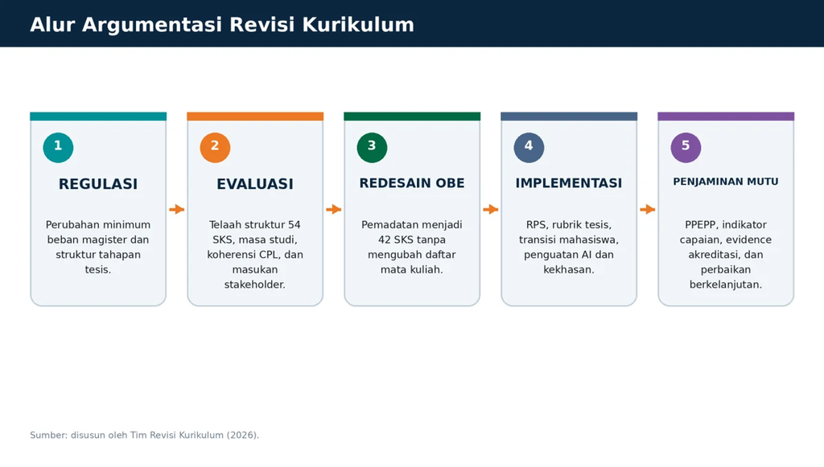

Gambar 1. Alur Argumentasi Revisi Kurikulum

Sumber: disusun oleh Tim Revisi Kurikulum (2026).

### 1.5 Prinsip Penyusunan

Naskah menggunakan prinsip kepatuhan regulasi, relevansi, efisiensi berbasis capaian, transparansi, fleksibilitas terarah, dan perbaikan berkelanjutan. Setiap perubahan harus dapat dilacak kepada dokumen, data, atau alasan akademik yang eksplisit. Perubahan yang belum memiliki dasar formal ditempatkan sebagai rekomendasi atau butir konfirmasi, bukan sebagai keputusan.

Halaman 13

## BAB II EVALUASI PELAKSANAAN KURIKULUM 2025

### 2.1 Gambaran Struktur Kurikulum 2025

Kurikulum 2025 jalur berbasis kuliah memuat 24 SKS mata kuliah wajib, 12 SKS mata kuliah pilihan yang harus ditempuh, dan 18 SKS tahapan penelitian tesis. Struktur tersebut memberikan penguatan metodologis yang luas, tetapi juga menempatkan beban akademik yang besar pada program yang diarahkan dapat selesai dalam tiga sampai empat semester.

Tabel 3. Komposisi Kurikulum 2025 Jalur Berbasis Kuliah

| Kelompok | Jumlah Komponen | SKS | Fungsi Akademik |
| --- | --- | --- | --- |
| Mata kuliah wajib | 8 | 24 | Fondasi inferensi, komputasi, multivariat, regresi, stokastik, deret waktu, nonparametrik, dan AI. |
| Mata kuliah pilihan yang ditempuh | 4 | 12 | Pendalaman sesuai minat dan topik tesis. |
| SUR | 1 | 3 | Proposal dan desain penelitian. |
| SKR | 1 | 6 | Pelaksanaan analisis dan evaluasi kemajuan. |
| SAM/Tesis | 1 | 9 | Finalisasi tesis dan ujian akhir. |
| Total |  | 54 |  |

Sumber: Kurikulum Program Studi Magister Statistika Terapan Tahun 2025.

### 2.2 Temuan Evaluasi Struktur

Evaluasi tidak menemukan alasan untuk menghapus mata kuliah dari katalog. Fondasi kurikulum masih relevan karena mencakup inferensi, komputasi, pemodelan multivariat, regresi, proses stokastik, deret waktu, nonparametrik, dan kecerdasan artifisial. Persoalan utama terletak pada proporsi beban wajib, jumlah mata kuliah pilihan yang harus ditempuh, dan bobot administratif-akademik tahapan tesis.

Tabel 4. Matriks Temuan Evaluasi Kurikulum 2025

| Aspek | Temuan | Implikasi Revisi |
| --- | --- | --- |
| Beban total | 54 SKS lebih tinggi daripada minimum baru universitas. | Perlu konsolidasi berbasis CPL, bukan pemotongan materi secara mekanis. |
| Tahapan tesis | SUR, SKR, dan SAM berjumlah 18 SKS. | Bobot dapat diselaraskan dengan minimum regulasi sambil memperkuat rubrik dan milestone. |
| Fleksibilitas | Empat mata kuliah pilihan diwajibkan. | Pengurangan menjadi tiga memberi ruang fokus tesis dan mengurangi fragmentasi. |
| Status nonparametrik | Wajib bagi seluruh mahasiswa. | Penting, tetapi kebutuhan kedalamannya berbeda menurut topik; tepat menjadi pilihan terarah. |
| Waktu mulai riset | Proposal berisiko terlambat bila riset baru intensif pada semester III. | SUR semester II memungkinkan sinkronisasi tema, data, etik, dan pembimbing lebih awal. |

Halaman 14

| Aspek | Temuan | Implikasi Revisi |
| --- | --- | --- |
| Integrasi AI | Terkonsentrasi pada beberapa mata kuliah. | Perlu integrasi longitudinal ke komputasi, pemodelan, validasi, etika, dan tesis. |

Sumber: hasil telaah kurikulum dan evaluasi akademik.

### 2.3 Masukan Stakeholder tentang Optimalisasi AI

Laporan jajak pendapat mencakup 31 stakeholder dari perguruan tinggi, pemerintah, industri, asosiasi profesi, dan kelompok lain. Hasilnya menunjukkan dukungan yang konsisten terhadap integrasi AI, namun dukungan tersebut selalu disertai penegasan bahwa fondasi statistika, pembelajaran praktis, dan etika tidak boleh dilemahkan.

Tabel 5. Indikator Utama Survei Optimalisasi AI

| Indikator | Rata-rata | Makna Kurikuler |
| --- | --- | --- |
| Relevansi AI | 4,61 | AI dinilai sangat relevan bagi kurikulum statistika. |
| Kebutuhan dunia kerja | 4,45 | Kompetensi AI dan statistika semakin berkelindan. |
| Pembelajaran praktis | 4,61 | Proyek berbasis data nyata dan konteks sektor perlu diperkuat. |
| Etika AI | 4,55 | Privasi, fairness, transparansi, audit, dan tanggung jawab harus menjadi capaian. |

Sumber: Laporan Jajak Pendapat Stakeholder Optimalisasi Kecerdasan Buatan dalam Kurikulum, pemutakhiran 19 Juli 2026.

Lima pesan strategis survei adalah mempertahankan identitas statistika, mengintegrasikan AI secara longitudinal, menaikkan intensitas praktik, mewajibkan responsible AI, dan membedakan kedalaman kompetensi S1 dan S2. Pada jenjang magister, mahasiswa tidak cukup mampu menjalankan algoritma; mereka harus mengevaluasi asumsi, robustness, uncertainty, fairness, reproducibility, dan konsekuensi keputusan.

### 2.4 Evaluasi Konsistensi Dokumen

Pemeriksaan lintas tabel menemukan beberapa ketidakkonsistenan yang tidak boleh diselesaikan melalui asumsi. Pertama, tabel struktur utama menempatkan SKR dan SAM pada semester III, sedangkan tabel lain menempatkan SKR pada semester II. Kedua, distribusi teori-praktik SUR, SKR, dan SAM berbeda antara tabel struktur, tabel RPL, dan tabel alur tesis. Ketiga, jalur berbasis riset masih memuat nilai lama pada beberapa bagian. Naskah ini menggunakan perubahan yang dinyatakan eksplisit oleh Program Studi—SUR semester II, SKR dan SAM mengikuti struktur final yang perlu disahkan—serta mencantumkan kebutuhan harmonisasi sebagai tindak lanjut.

Tabel 6. Ketidakkonsistenan Data yang Memerlukan Klarifikasi

| Isu | Temuan | Tindak Lanjut |
| --- | --- | --- |
| Penempatan SKR | Ada tabel yang menempatkan semester II dan ada yang semester III. | Tetapkan satu semester final melalui keputusan kurikulum dan samakan seluruh tabel/RPS. |

Halaman 15

| Isu | Temuan | Tindak Lanjut |
| --- | --- | --- |
| Komposisi teori-praktik | SUR 2 (1-1) vs 2 (1-2); SKR 4 (2-2) vs 4 (3-3); SAM 6 (3-3) vs 6 (3-6). | Gunakan notasi SKS sesuai definisi aktivitas akademik yang berlaku dan konsisten. |
| Jalur riset/RPL | Sebagian tabel masih menunjukkan bobot 3/6/9. | Lakukan audit seluruh tabel sebelum pengesahan. |
| Nama dokumen | “OBE 2026” dan “Kurikulum 2025 Revisi 2026” digunakan bersamaan. | Tetapkan nomenklatur resmi untuk cover, SK, PDDikti, dan dokumen akreditasi. |

Sumber: hasil pemeriksaan dokumen Kurikulum 2025 dan dokumen revisi 42 SKS.

### 2.5 Rumusan Masalah Revisi

Berdasarkan evaluasi, revisi harus menjawab empat pertanyaan: bagaimana menurunkan beban menjadi 42 SKS secara transparan; bagaimana menjaga kedalaman KKNI level 8; bagaimana memulai riset lebih awal tanpa membebani semester II; dan bagaimana memperkuat AI serta kekhasan kesehatan tanpa menambah mata kuliah atau membuat klaim kelembagaan yang tidak tersedia.

Halaman 16

## BAB III LANDASAN FILOSOFIS, SOSIOLOGIS, YURIDIS, DAN AKADEMIK

### 3.1 Landasan Filosofis

Pendidikan magister statistika terapan bertujuan membentuk kemampuan mengembangkan dan menerapkan pengetahuan melalui penalaran ilmiah. Kebenaran statistik tidak hanya ditentukan oleh kecocokan algoritma, tetapi oleh kualitas desain, data, asumsi, inferensi, ketidakpastian, dan keterbukaan proses. Karena itu, efisiensi kurikulum harus menjaga ruang refleksi metodologis dan tanggung jawab terhadap dampak keputusan.

### 3.2 Landasan Sosiologis

Masyarakat memerlukan analisis yang dapat dipercaya untuk kesehatan, ekonomi, industri, perlindungan sosial, risiko, dan kebijakan publik. Pada saat yang sama, otomatisasi analitik membuat hasil yang tampak presisi dapat diproduksi tanpa pemahaman memadai. Program Studi perlu menghasilkan lulusan yang mampu menjadi penghubung antara masalah substantif, data, metode, dan keputusan; bukan sekadar operator perangkat lunak.

### 3.3 Landasan Yuridis

Dasar hukum utama adalah Peraturan Rektor Universitas Padjadjaran Nomor 31 Tahun 2026, yang mengubah Pasal 24–26 penyelenggaraan program magister. Regulasi tersebut menetapkan minimum 36 SKS dan komponen minimum jalur berbasis kuliah maupun berbasis riset. Penetapan 42 SKS oleh Program Studi berada di atas minimum dan harus disertai rasional akademik serta keputusan fakultas yang terdokumentasi.

Tabel 7. Landasan Hukum dan Kebijakan Revisi Kurikulum

| Dokumen | Relevansi |
| --- | --- |
| Undang-Undang Nomor 12 Tahun 2012 tentang Pendidikan Tinggi | Menegaskan pendidikan tinggi, tridharma, kurikulum, mutu, dan otonomi akademik. |
| Peraturan Presiden Nomor 8 Tahun 2012 tentang KKNI | Menempatkan lulusan magister pada level 8 dengan kemampuan mengembangkan pengetahuan dan menyelesaikan masalah multidisipliner.1 |
| Peraturan Pemerintah Nomor 4 Tahun 2014 | Mengatur penyelenggaraan dan pengelolaan pendidikan tinggi. |
| Permendiktisaintek Nomor 39 Tahun 2025 | Mengatur SN-Dikti, standar perguruan tinggi, SPMI/SPME, akreditasi, dan PDDikti; menggantikan ketentuan penjaminan mutu sebelumnya.2 |
| Peraturan Rektor Unpad Nomor 31 Tahun 2026 | Menetapkan minimum 36 SKS serta komponen SUR, SKR, SAM, dan ketentuan jalur berbasis riset.3 |

Halaman 17

| Dokumen | Relevansi |
| --- | --- |
| Instrumen/Kriteria LAMSAMA | Menekankan konsistensi visi, CPL, kurikulum, pembelajaran, asesmen, sumber daya, luaran, dan perbaikan berkelanjutan.4 |
| Kriteria ASIIN | Menekankan profil program, intended learning outcomes, desain kurikulum, beban kerja, asesmen, sumber daya, transparansi, dan quality management.5 |
| SE Menkominfo Nomor 9 Tahun 2023 | Memberikan pedoman etika AI: inklusivitas, kemanusiaan, keamanan, aksesibilitas, transparansi, kredibilitas, akuntabilitas, perlindungan data, dan keberlanjutan.6 |

Sumber: dokumen resmi sebagaimana dirinci dalam footnote dan daftar pustaka.

### 3.4 Landasan Akademik dan OBE

Outcome-Based Education menempatkan capaian lulusan sebagai titik awal desain. Perubahan jumlah SKS hanya dapat dibenarkan bila ketercapaian CPL tetap terjamin melalui pemetaan yang eksplisit, learning activities yang memadai, dan asesmen yang valid. Karena itu, revisi harus diikuti pembaruan matriks CPL-mata kuliah, CPMK, rubrik, dan bukti beban belajar.

Konsolidasi beban dilakukan dengan mengurangi redundansi dan memperjelas fungsi setiap komponen. Materi nonparametrik tidak hilang karena tetap tersedia sebagai pilihan; kompetensi metode fleksibel juga dapat muncul pada regresi lanjut, analisis spasial, survival, dan pembelajaran mesin. Kualitas tesis tidak bergantung pada angka SKS semata, melainkan pada kualitas supervisi, milestone, seminar, data, analisis, naskah, dan publikasi.

### 3.5 Landasan Penjaminan Mutu dan Akreditasi

LAMSAMA dan ASIIN sama-sama menuntut koherensi antara tujuan, CPL, kurikulum, asesmen, sumber daya, dan hasil. Struktur 42 SKS dapat mendukung akreditasi bila program menunjukkan: keterukuran beban belajar; distribusi teori-praktik; capaian metodologis level magister; integrasi komputasi; penelitian yang memadai; kompetensi profesional; dan siklus evaluasi yang terdokumentasi.

Halaman 18

## BAB IV PERKEMBANGAN ILMU STATISTIKA, SAINS DATA, DAN KECERDASAN ARTIFISIAL

### 4.1 Konvergensi Statistika dan Sains Data

Sains data memperluas ruang kerja statistika melalui komputasi skala besar, integrasi data, visualisasi, dan deployment model. Namun, kualitas keputusan tetap bergantung pada desain pengumpulan data, representativitas, missingness, measurement error, confounding, dan uncertainty. Kurikulum magister harus mengajarkan mahasiswa untuk menghubungkan workflow komputasi dengan pertanyaan inferensial.

### 4.2 Peran AI dalam Pendidikan Statistika

AI dapat membantu eksplorasi literatur, penulisan kode, simulasi, pemodelan, visualisasi, dan komunikasi. Penggunaan tersebut hanya bernilai akademik bila mahasiswa mampu memverifikasi keluaran, mencatat prompt dan transformasi penting, melindungi data, menguji reproducibility, serta bertanggung jawab atas interpretasi akhir. UNESCO merekomendasikan pendekatan human-centred, perlindungan privasi, validasi etis-pedagogis, dan pengembangan kapasitas institusi.7

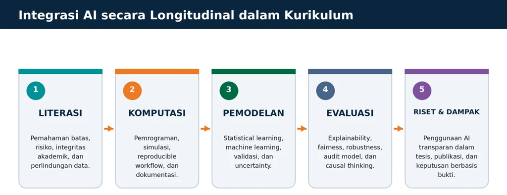

Gambar 2. Integrasi AI secara Longitudinal dalam Kurikulum

Sumber: disusun oleh Tim Revisi Kurikulum (2026).

7UNESCO, Guidance for Generative AI in Education and Research, Paris, 2023; laman diperbarui 16 Januari 2026, diakses 21 Juli 2026.

Halaman 19

### 4.3 Kompetensi AI yang Relevan pada Jenjang Magister

Tabel 8. Domain Kompetensi Sains Data dan AI pada Jenjang Magister

| Domain | Substansi | Capaian |
| --- | --- | --- |
| Fondasi | Probabilitas, inferensi, optimasi, algoritma, dan evaluasi ketidakpastian. | Membedakan prediksi, estimasi, dan klaim kausal. |
| Komputasi | Pemrograman, version control, reproducible pipeline, simulasi, dan komputasi efisien. | Menghasilkan analisis yang dapat ditelusuri dan direplikasi. |
| Pemodelan | Statistical learning, machine learning, model selection, regularisasi, dan validasi. | Memilih model berdasarkan tujuan dan struktur data. |
| Evaluasi | Cross-validation yang tepat, calibration, robustness, fairness, explainability, dan audit. | Menilai model melampaui akurasi agregat. |
| Tata kelola | Privasi, keamanan data, dokumentasi, keterlacakan, lisensi, dan integritas akademik. | Menjaga kepercayaan dan kepatuhan. |
| Komunikasi | Pelaporan uncertainty, visualisasi, model card, dan rekomendasi keputusan. | Mencegah overclaim serta menyampaikan batas model. |

Sumber: sintesis literatur, survei stakeholder, dan pedoman etika AI.

### 4.4 Responsible AI dan Integritas Akademik

Responsible AI harus hadir sebagai learning outcome lintas mata kuliah. Mahasiswa perlu mampu mengidentifikasi potensi diskriminasi, data leakage, distribution shift, ketergantungan pada proxy, dan konsekuensi penggunaan model. Pada penggunaan AI generatif, transparansi minimum meliputi alat dan versi, tujuan penggunaan, bagian pekerjaan yang dibantu, verifikasi yang dilakukan, serta pernyataan bahwa penulis bertanggung jawab penuh atas hasil.

### 4.5 Implikasi terhadap Silabus

Integrasi AI tidak memerlukan mata kuliah baru apabila silabus yang ada ditata secara longitudinal. Komputasi Statistik dan Optimasi menjadi fondasi workflow; Statistika Inferensial menegaskan uncertainty; Regresi dan Multivariat membandingkan pendekatan klasik-modern; Deret Waktu membahas validasi temporal; Penambangan Data dan AI menjadi ruang utama machine learning, explainability, dan governance; mata kuliah pilihan menerapkan kompetensi pada domain masing-masing.

Halaman 20

## BAB V KEKHASAN PROGRAM STUDI DALAM STATISTIKA KESEHATAN DAN SAINS DATA-AI

### 5.1 Rasional Kekhasan

Kekhasan program tidak dimaksudkan membatasi seluruh topik tesis, melainkan memberi identitas yang konsisten terhadap sumber daya dan kebutuhan lingkungan. Statistika kesehatan dan sains data-AI dipilih sebagai dua pilar yang saling menguatkan. Bidang bisnis-industri, sosial, aktuaria, statistik resmi, dan bidang terapan lain tetap dipertahankan sebagai ruang aplikasi dan pilihan akademik.

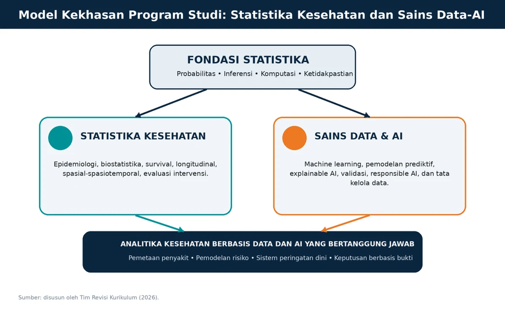

Gambar 3. Model Kekhasan Program Studi: Statistika Kesehatan dan Sains Data-AI

Sumber: disusun oleh Tim Revisi Kurikulum (2026).

### 5.2 Statistika Kesehatan

Penguatan statistika kesehatan ditopang oleh keberadaan Fakultas Kedokteran Unpad dan jejaring rumah sakit pendidikan yang dikoordinasikan bersama RSHS. Lingkungan ini membuka peluang kolaborasi pada desain studi, analisis klinis, epidemiologi, evaluasi layanan, dan kebijakan kesehatan. Peluang tersebut harus diwujudkan melalui kerja sama formal, persetujuan etik, data management plan, anonimisasi, dan pembatasan akses berbasis kebutuhan.

Kekuatan metodologis yang relevan meliputi analisis survival, data longitudinal, multilevel, model linear generalisasi, pemetaan penyakit, spasial-spasiotemporal, Bayesian, causal inference, evaluasi intervensi, dan sistem peringatan dini. Kurikulum tidak harus menjanjikan seluruh metode sebagai mata kuliah wajib; kombinasi mata kuliah inti, pilihan, studi kasus, guest lecture, dan tesis dapat membentuk kedalaman yang memadai.

Halaman 21

### 5.3 Sains Data dan Kecerdasan Artifisial

Kekhasan sains data-AI diletakkan pada kemampuan menghasilkan analisis yang akurat, dapat dijelaskan, tervalidasi, dan bertanggung jawab. Mahasiswa tidak hanya belajar algoritma, tetapi juga merumuskan target, menentukan unit analisis, mencegah leakage, menyusun data split sesuai struktur, menilai calibration, membandingkan model, dan mengomunikasikan ketidakpastian.

### 5.4 Integrasi Dua Pilar

Tabel 9. Contoh Integrasi Statistika Kesehatan dan Sains Data-AI

| Ruang Aplikasi | Data | Pendekatan | Isu Mutu dan Etika |
| --- | --- | --- | --- |
| Analitika penyakit menular | Data surveilans, cuaca, mobilitas, dan wilayah | Model spasiotemporal, forecasting, early warning | Validasi temporal-spasial, uncertainty, fairness antardaerah |
| Prediksi risiko klinis | Rekam medis dan data laboratorium | Survival, machine learning, calibration | Privasi, missingness, transportability, interpretability |
| Evaluasi intervensi | Data observasional/eksperimen tal | Causal inference, multilevel, longitudinal | Confounding, estimand, sensitivity analysis |
| Pemetaan akses layanan | Data fasilitas, penduduk, dan geospasial | Spatial accessibility, small-area estimation | Heterogenitas wilayah dan kualitas data |
| Pengambilan keputusan kesehatan | Data multi-sumber | Decision dashboard dan uncertainty-aware AI | Audit model, keterlacakan, dan komunikasi risiko |

Sumber: disusun sebagai ilustrasi arah kekhasan; bukan daftar topik yang bersifat membatasi.

### 5.5 Batas Klaim Kekhasan

Dokumen menggunakan istilah “didukung oleh ekosistem”, “memiliki peluang”, dan “diarahkan untuk diperkuat”. Istilah tersebut sengaja dipilih agar tidak menyatakan bahwa Program Studi memiliki akses otomatis ke data pasien, seluruh fasilitas rumah sakit, atau kemitraan eksklusif. Klaim operasional baru dapat digunakan setelah tersedia perjanjian kerja sama, persetujuan etik, prosedur keamanan, penanggung jawab data, dan bukti aktivitas bersama.

Halaman 22

## BAB VI HASIL STUDI BANDING NASIONAL DAN INTERNASIONAL

### 6.1 Metode dan Batas Perbandingan

Studi banding menggunakan laman program, handbook, atau dokumen kurikulum resmi yang tersedia hingga 21 Juli 2026. Perbandingan kredit bersifat deskriptif. SKS Indonesia, ECTS, NUS Units, Oxford units, dan Melbourne credit points memiliki definisi beban belajar yang berbeda dan tidak dikonversi secara langsung. Fokus analisis adalah arsitektur kurikulum, posisi penelitian, kedalaman komputasi, fleksibilitas, dan domain aplikasi.

Halaman 23

### 6.2 Benchmarking Nasional

Tabel 10. Perbandingan Program Magister Nasional

| Institusi | Program | Negara | Durasi | Beban | Struktur | Tesis/Capstone | Kesehatan/Data-AI | Pelajaran bagi Unpad |
| --- | --- | --- | --- | --- | --- | --- | --- | --- |
| ITS | S2 Statistika | Indonesia | 4 semester | 36 SKS | 12+12+6+6; jalur reguler dan riset | Proposal tesis semester III; tesis semester IV | Komputasi statistika intensif; pilihan kesehatan/lingkun gan | Struktur ringkas dan proporsi tesis jelas.8 |
| IPB University | Magister Statistika dan Sains Data | Indonesia | Mengikuti ketentuan magister IPB | Dokumen rinci publik K2020/portal 2025; tidak disetarakan tanpa verifikasi | Statistika dan sains data; orientasi riset dan in-depth courses | Tesis/riset mengikuti tata tertib pascasarjana | Statistical programming, data science, dan metode lanjut | Penguatan identitas statistika-sains data dan kultur riset.9 |
| Universitas Islam Indonesia | Magister Statistika | Indonesia | 4 semester | 42 SKS | 12+12+9+9 | Proposal semester III; tesis, publikasi, ujian terbuka/tertutup semester IV | Dasar sains data; pilihan deep learning, spatial data science, genomics | Contoh langsung struktur 42 SKS dengan fleksibilitas pilihan.10 |
| Universitas Brawijaya | Magister Statistika | Indonesia | 4 semester | Minimum 36 SKS | Jalur reguler dan penelitian | Tesis I/proposal 4; Tesis II 8; publikasi dan seminar | Komputasi; pilihan spasial, nonparametrik, longitudinal, health/energy | Milestone tesis dan dua jalur implementasi.11 |

Sumber: laman dan dokumen kurikulum resmi masing-masing institusi; akses 21 Juli 2026.

Halaman 24

### 6.3 Benchmarking Internasional

Tabel 11. Perbandingan Program Magister Internasional

| Institusi | Program | Negara | Durasi | Sistem Kredit | Struktur | Tesis/Capstone | Kesehatan/Data-AI | Pelajaran bagi Unpad |
| --- | --- | --- | --- | --- | --- | --- | --- | --- |
| University of Oxford | MSc Statistical Science | Britania Raya | 12 bulan | 9 course units; sistem Oxford | Lima core, options, practical assignments | Disertasi riset independen pada bagian akhir program | Statistical programming, computational statistics, statistical machine learning | Fondasi inferensi-komputasi kuat dengan durasi intensif.12 |
| ETH Zurich | MSc Statistics | Swiss | 1,5 tahun | 90 ECTS | Sekitar 60 ECTS coursework dan 30 ECTS tesis | Tesis satu semester sebagai penutup | Core statistics, electives, Statistics Lab/consulting | Proporsi tesis besar dan laboratorium konsultasi nyata.13 |
| National University of Singapore | MSc Statistics | Singapura | 1–2 tahun penuh waktu | 40 Units/10 courses | Lima core dan lima elective | Jalur coursework; project tersedia sebagai pilihan | Statistical foundations of data science, spatial, survival, learning, deep learning | Fleksibilitas tinggi dan jalur profesi/data scientist.14 |
| University of Melbourne | Master of Biostatistics | Australia | 18 bulan penuh waktu | 150 credit points | Core biostatistics, electives, dan project/capstone | Proyek riset kesehatan atau capstone terapan | Survival, longitudinal, clinical trials, Bayesian, bioinformatics | Benchmark kuat untuk statistika kesehatan dan proyek nyata.15 |

Catatan: unit kredit tidak dikonversi langsung ke SKS Indonesia. Sumber resmi; akses 21 Juli 2026.

Halaman 25

### 6.4 Analisis Posisi Kurikulum Revisi

Beban 42 SKS menempatkan Unpad di atas minimum 36 SKS yang lazim digunakan ITS dan UB, serta setara secara nominal dengan UII. Keunggulan potensial Unpad bukan pada jumlah kredit, melainkan pada integrasi fondasi statistika, pilihan yang luas, riset tiga tahap, dan kekhasan kesehatan–AI. Struktur tiga semester dapat kompetitif apabila SUR benar-benar dimulai pada semester II dan SKR/SAM dikelola dengan milestone yang realistis.

Benchmark internasional memperlihatkan dua pola. Program coursework seperti NUS menekankan fleksibilitas dan pilihan; program seperti ETH menempatkan tesis sebagai porsi besar; Oxford menggabungkan coursework intensif dan disertasi singkat; Melbourne menonjolkan domain kesehatan dan proyek profesional. Kurikulum Unpad dapat mengambil kombinasi: core metodologis kuat, pilihan terarah, penelitian dimulai dini, dan proyek tesis yang terdokumentasi.

Tabel 12. Posisi Kurikulum Unpad terhadap Temuan Benchmarking

| Dimensi | Posisi Revisi 2026 | Interpretasi |
| --- | --- | --- |
| Core metodologis | Dipertahankan 18 SKS semester I dan 3 SKS Penambangan Data-AI. | Selaras dengan Oxford/ITS/UB yang mempertahankan fondasi. |
| Fleksibilitas | Tiga pilihan dari katalog luas. | Selaras dengan NUS/ETH; perlu academic advising. |
| Tesis | 12 SKS dengan tiga milestone. | Lebih kecil secara angka daripada struktur lama; kualitas harus dijaga melalui rubrik, bukan kredit. |
| Kesehatan | Pilihan epidemiologi, survival, longitudinal, spasial. | Memiliki bahan dasar untuk kekhasan seperti Melbourne, perlu proyek/mitra nyata. |
| AI/komputasi | Mata kuliah wajib dan integrasi longitudinal. | Selaras dengan perkembangan Oxford/NUS; responsible AI menjadi pembeda. |
| Durasi | Dirancang 3 semester. | Lebih cepat daripada banyak program nasional 4 semester; perlu pengendalian data dan pembimbing sejak semester I. |

Sumber: analisis benchmarking.

Halaman 26

## BAB VII RANCANGAN PERUBAHAN KURIKULUM

### 7.1 Prinsip Rancangan

Rancangan mempertahankan daftar mata kuliah dan kode yang tersedia. Perubahan meliputi bobot tahapan tesis, status satu mata kuliah, jumlah pilihan yang wajib ditempuh, serta penempatan SUR. Materi, CPMK, dan asesmen disempurnakan agar 42 SKS tetap mencapai CPL secara utuh.

### 7.2 Rekonsiliasi Perubahan 54 menjadi 42 SKS

Rekonsiliasi menunjukkan selisih tepat 12 SKS tanpa asumsi tambahan. Pengurangan 6 SKS pada tesis mengikuti batas minimum Peraturan Rektor. Perubahan Nonparametrik menjadi pilihan mengurangi beban wajib 3 SKS, tetapi tidak menghapus akses mahasiswa terhadap mata kuliah. Pengurangan pilihan yang harus ditempuh dari empat menjadi tiga menghasilkan 3 SKS terakhir.

Tabel 13. Perhitungan Lengkap Perubahan Beban Studi

| Komponen | 2025 | Revisi 2026 | Selisih | Catatan |
| --- | --- | --- | --- | --- |
| Mata kuliah wajib inti selain Nonparametrik | 21 | 21 | 0 | Tetap |
| Statistika Nonparametrik dan Pemodelan Fleksibel | 3 wajib | 3 pilihan | -3 pada beban wajib | Tersedia dalam katalog pilihan |
| Mata kuliah pilihan lain yang wajib ditempuh | 12 (4 MK) | 9 (3 MK) | -3 | Fleksibilitas meningkat |
| Seminar Usulan Riset | 3 | 2 | -1 | Semester II |
| Seminar Kemajuan Riset | 6 | 4 | -2 | Semester final perlu dikonfirmasi |
| Sidang Akhir Magister | 9 | 6 | -3 | Tetap tahap akhir |
| Total | 54 | 42 | -12 | Rekonsiliasi lengkap |

Sumber: pemeriksaan tabel struktur Kurikulum 2025 dan revisi 42 SKS.

### 7.3 Perbandingan Rinci Perubahan

Halaman 27

Tabel 14. Perbandingan Kurikulum 2025 dan Kurikulum 2025 Revisi Tahun 2026

| Komponen | Sem Lama | Sem Baru | SKS Lama | SKS Baru | Status Lama | Status Baru | Bentuk Perubahan | Alasan Akademik | Implikasi Pembelajaran |
| --- | --- | --- | --- | --- | --- | --- | --- | --- | --- |
| SUR | III | II | 3 | 2 | Wajib | Wajib | Bobot turun dan dimajukan | Memulai proposal, etik, data, dan pembimbing lebih awal. | Semester II memuat milestone proposal yang terukur. |
| SKR | III | III* | 6 | 4 | Wajib | Wajib | Bobot turun | Efisiensi tahap kemajuan; fokus pada bukti analisis dan validasi. | Rubrik, logbook, dan minimum output wajib menjaga mutu. |
| SAM/Tesis | III | III | 9 | 6 | Wajib | Wajib | Bobot turun | Selaras minimum regulasi; menghindari penghitungan ganda aktivitas. | Kualitas naskah, publikasi, dan ujian tidak dikurangi. |
| Statistika Nonparametrik dan Pemodelan Fleksibel | II | II | 3 | 3 | Wajib | Pilihan | Status berubah | Memberi fleksibilitas menurut topik dan profesi. | Academic advising memastikan mahasiswa yang memerlukan tetap mengambil. |
| Mata kuliah pilihan yang ditempuh | II | II | 12 | 9 | 4 pilihan | 3 pilihan | Jumlah berkurang | Mengurangi fragmentasi dan memberi waktu tesis. | Mahasiswa menyusun paket pilihan yang koheren. |
| Total program | I–III | I–III | 54 | 42 | Wajib program | Wajib program | -12 SKS | Keseimbangan efisiensi, kedalaman, dan riset. | Beban belajar dan CPL dipantau melalui RPS dan asesmen. |

*Penempatan SKR mengikuti arahan utama naskah (semester III); tabel dokumen yang menempatkan SKR semester II harus diharmonisasi sebelum pengesahan.

Halaman 28

### 7.4 Struktur Kurikulum Revisi per Semester

Tabel 15. Struktur Kurikulum 2025 Revisi Tahun 2026 per Semester

| Semester | Mata Kuliah/Kegiatan | Status | SKS |
| --- | --- | --- | --- |
| I | Statistika Inferensial | W | 3 |
| I | Komputasi Statistik dan Optimasi | W | 3 |
| I | Analisis Multivariat Tingkat Lanjut | W | 3 |
| I | Analisis Regresi Tingkat Lanjut | W | 3 |
| I | Proses Stokastik Tingkat Lanjut | W | 3 |
| I | Analisis Deret Waktu Tingkat Lanjut | W | 3 |
| II | Penambangan Data dan Kecerdasan Buatan | W | 3 |
| II | Mata Kuliah Pilihan 1 | P | 3 |
| II | Mata Kuliah Pilihan 2 | P | 3 |
| II | Mata Kuliah Pilihan 3 | P | 3 |
| II | Seminar Usulan Riset | W | 2 |
| III | Seminar Kemajuan Riset | W | 4 |
| III | Sidang Akhir Magister (Tesis) | W | 6 |

Total Semester I = 18 SKS; Semester II = 14 SKS; Semester III = 10 SKS; total = 42 SKS. Struktur ini mengikuti perubahan eksplisit dalam naskah; penempatan SKR perlu disahkan untuk menghilangkan perbedaan antartabel.

Distribusi 18–14–10 SKS memberi ruang bagi tahap penelitian yang makin intensif. Pada semester I, orientasi tesis harus sudah dimulai melalui pemetaan minat, klinik proposal, dan penetapan calon pembimbing. Semester II menggabungkan pendalaman AI/pilihan dengan SUR. Semester III berfokus pada analisis, penulisan, diseminasi, dan ujian.

### 7.5 Dampak terhadap CPL dan Bahan Kajian

CPL tidak perlu dikurangi. Perubahan status dan jumlah pilihan memerlukan penyesuaian kontribusi persentase mata kuliah terhadap CPL agar total tetap logis. CPL yang semula sangat bergantung pada empat pilihan harus dipenuhi melalui mata kuliah wajib, tiga pilihan, dan asesmen tesis. Matriks CPL-mata kuliah perlu dihitung ulang berdasarkan bobot asesmen, bukan sekadar membagi persentase menurut SKS.

Tabel 16. Rekonstruksi Pengampu Utama CPL setelah Revisi

| Kelompok CPL | Pengampu Utama | Bukti Asesmen |
| --- | --- | --- |
| CPL pengetahuan metodologis | Mata kuliah wajib semester I dan Data Mining-AI | Ujian analitik, proyek pemodelan, kritik artikel. |
| CPL pemecahan masalah | Mata kuliah pilihan dan tesis | Studi kasus, problem formulation, model comparison. |
| CPL komputasi | Komputasi, Regresi, Multivariat, Deret Waktu, AI | Repository, reproducible report, unit test/simulation. |

Halaman 29

| Kelompok CPL | Pengampu Utama | Bukti Asesmen |
| --- | --- | --- |
| CPL riset | SUR, SKR, SAM | Proposal, logbook, analisis, manuskrip, ujian. |
| CPL komunikasi dan etika | Seluruh mata kuliah dan tesis | Presentasi, peer review, disclosure AI, data governance. |

Sumber: rekomendasi desain OBE.

### 7.6 Penyempurnaan Silabus dan Integrasi AI

Tabel 17. Matriks Penyempurnaan Silabus tanpa Menambah Mata Kuliah

| Mata Kuliah/Kelompok | Integrasi yang Disarankan | Capaian |
| --- | --- | --- |
| Statistika Inferensial | Inferensi vs prediksi; uncertainty; robustness; selective inference. | Mengevaluasi keluaran AI dan menyatakan batas inferensi. |
| Komputasi Statistik dan Optimasi | Reproducible workflow, version control, simulasi, optimasi, AI-assisted coding. | Kode dapat diaudit; verifikasi keluaran generatif. |
| Multivariat Lanjut | Dimensionality reduction, clustering, representation, validation. | Membandingkan metode klasik dan modern. |
| Regresi Lanjut | Regularisasi, model selection, calibration, explainability. | Membedakan penjelasan, prediksi, dan kausalitas. |
| Proses Stokastik | Monte Carlo, probabilistic modeling, uncertainty propagation. | Membangun simulasi dan menilai ketidakpastian. |
| Deret Waktu Lanjut | Rolling-origin validation, forecast uncertainty, hybrid models. | Mencegah leakage dan mengevaluasi stabilitas temporal. |
| Penambangan Data dan AI | ML, deep learning pengantar, XAI, fairness, audit, governance. | Membangun dan mengevaluasi model responsible AI. |
| Pilihan Kesehatan | Survival, epidemiologi, longitudinal, spasial. | Menerapkan AI/statistika pada data kesehatan dengan etika. |
| SUR/SKR/SAM | Disclosure AI, data management, reproducibility, model card. | Tesis transparan dan dapat dipertanggungjawabkan. |

Sumber: sintesis survei stakeholder dan kebutuhan responsible AI.

### 7.7 Penguatan Mekanisme SUR, SKR, dan SAM

Pengurangan bobot SKS harus diimbangi mekanisme akademik yang lebih tajam. SUR menilai masalah, novelty, literature map, desain, data, etik, feasibility, dan rencana analisis. SKR menilai keterlaksanaan data, quality control, analisis utama, validasi, uncertainty, dan draf hasil. SAM menilai kontribusi, ketepatan metode, keterlacakan analisis, kualitas naskah, komunikasi, dan tanggung jawab etik.

Tabel 18. Milestone Pengendalian Mutu Tesis

| Tahap | Waktu | Output Minimum |
| --- | --- | --- |
| Pra-SUR | Akhir semester I–awal II | Topik, pembimbing, literature map, data availability, ethical screening. |
| SUR | Semester II | Proposal lengkap, metodologi, rencana analisis, timeline, DMP. |
| Pasca-SUR | Maks. 4 minggu | Revisi disetujui; logbook dan repository dibuat. |

Halaman 30

| Tahap | Waktu | Output Minimum |
| --- | --- | --- |
| SKR | Semester III | Data/analisis minimum, diagnostics, validation, draft results. |
| Pra-SAM | Setelah SKR | Draf penuh, similarity check, disclosure AI, bukti diseminasi/publikasi. |
| SAM | Semester III | Ujian tesis dan keputusan kelulusan. |
| Pasca-SAM | Maks. 2–4 minggu | Revisi final, arsip data/kode sesuai izin, unggah repositori institusi. |

Waktu revisi final perlu diselaraskan dengan peraturan akademik Unpad.

### 7.8 Jalur Berbasis Riset dan RPL

Peraturan Rektor menetapkan jalur berbasis riset sekurang-kurangnya 15 SKS kompetensi, SUR 2, SKR 4, SAM 6, dan publikasi 9 SKS. Dokumen revisi memuat rancangan total 42 SKS, tetapi beberapa tabel RPL masih menunjukkan bobot lama. Program Studi perlu menerbitkan tabel tunggal untuk setiap jalur yang memuat kode, status, semester, SKS, kelayakan RPL, dan kontribusi CPL.

Halaman 31

## BAB VIII ANALISIS DAMPAK DAN STRATEGI IMPLEMENTASI

### 8.1 Dampak terhadap Proses Pembelajaran

Tabel 19. Analisis Dampak Revisi Kurikulum

[output not shown]

Sumber: analisis implementasi.

### 8.2 Strategi Implementasi Bertahap

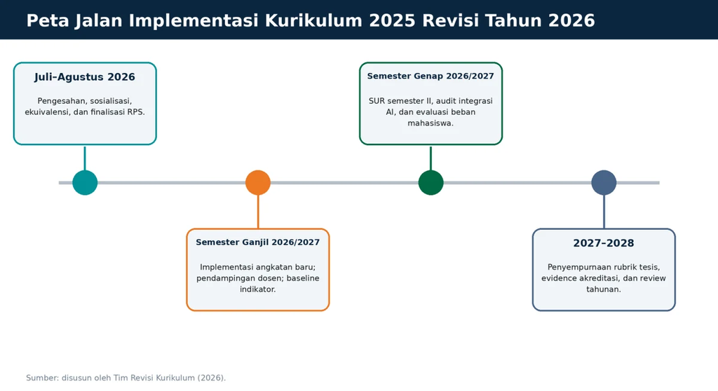

Gambar 4. Peta Jalan Implementasi Kurikulum 2025 Revisi Tahun 2026

Sumber: disusun oleh Tim Revisi Kurikulum (2026).

Halaman 32

### 8.3 Masa Transisi Mahasiswa

Prinsip transisi adalah tidak merugikan mahasiswa dan tidak menurunkan pengakuan atas aktivitas yang telah ditempuh. Mahasiswa angkatan sebelum 2026/2027 pada dasarnya tetap mengikuti kurikulum saat registrasi, kecuali memilih migrasi berdasarkan ekuivalensi dan persetujuan Program Studi. Mata kuliah yang telah lulus tidak diulang. Kelebihan SKS dapat dicatat dalam transkrip sesuai kebijakan akademik.

Tabel 20. Rancangan Ketentuan Transisi Mahasiswa

| Kondisi | Ketentuan | Catatan |
| --- | --- | --- |
| Belum mengambil SUR | Dapat mengikuti struktur revisi setelah persetujuan PA/KPS. | Mata kuliah lulus diakui; kebutuhan total dihitung berdasarkan ekuivalensi. |
| Sudah lulus SUR 3 SKS | Diakui penuh; tidak dikurangi menjadi 2 pada transkrip. | Melanjutkan SKR/SAM sesuai skema transisi yang ditetapkan. |
| Sedang/selesai SKR 6 SKS | Diakui penuh. | Tidak wajib mengulang SKR 4 SKS. |
| Sudah mengambil Nonparametrik saat wajib | Diakui sebagai pemenuhan mata kuliah; status transkrip mengikuti saat ditempuh. | Dapat dihitung dalam paket pilihan jika migrasi. |
| Sudah menempuh empat pilihan | Semua tetap diakui. | Kelebihan dicatat sebagai mata kuliah tambahan sesuai aturan. |
| Mahasiswa RPL/jalur riset | Diperiksa kasus per kasus berdasarkan tabel final. | Keputusan ekuivalensi tertulis dan terdokumentasi. |

Status final memerlukan pengesahan fakultas/universitas.

### 8.4 Risiko Implementasi dan Mitigasi

Tabel 21. Register Risiko Implementasi

| Risiko | Penyebab/Dampak | Mitigasi |
| --- | --- | --- |
| Kepadatan semester II | Pilihan, AI, dan SUR berlangsung bersamaan. | Pra-proposal semester I; kalender SUR; batas jumlah proyek simultan. |
| Mutu tesis turun akibat SKS lebih kecil | SKS dianggap identik dengan mutu. | Rubrik, logbook, panel review, dan standar output minimum. |
| Integrasi AI bersifat kosmetik | AI hanya muncul dalam narasi. | CPMK, tugas, rubrik, repository, disclosure, dan audit RPS. |
| Kebocoran data kesehatan | Penggunaan data sensitif tanpa tata kelola. | DMP, etik, anonimisasi, akses berbasis peran, larangan unggah ke GenAI publik. |
| Pilihan tidak koheren | Mahasiswa memilih berdasarkan jadwal. | Paket rekomendasi per minat dan persetujuan PA. |
| Dokumen tidak konsisten | Tabel/RPS/PDDikti berbeda. | Single source of truth dan audit dokumen sebelum semester berjalan. |
| Beban dosen pembimbing | SUR dimulai lebih awal untuk semua mahasiswa. | Kuota pembimbing, dashboard, co-supervision, dan distribusi topik. |

Sumber: analisis risiko kurikulum.

### 8.5 Kebutuhan Sumber Daya

Kebutuhan utama meliputi laboratorium komputer, komputasi server/cloud yang dikelola institusi, repository kode, penyimpanan aman, perangkat kolaborasi, akses jurnal, data

Halaman 33

sintetis/terbuka untuk praktikum, serta staf pendukung. Untuk data kesehatan, penggunaan lingkungan aman dan pemisahan data identitas dari data analitik menjadi prioritas. Program Studi juga perlu pelatihan dosen mengenai reproducibility, AI-assisted assessment, keamanan data, dan penilaian autentik.

Halaman 34

## BAB IX PENJAMINAN MUTU, MONITORING, DAN EVALUASI

### 9.1 Kerangka PPEPP

Penjaminan mutu mengikuti siklus Penetapan, Pelaksanaan, Evaluasi, Pengendalian, dan Peningkatan. Penetapan mencakup CPL, struktur 42 SKS, RPS, rubrik, dan kebijakan AI. Pelaksanaan menghasilkan bukti pembelajaran. Evaluasi menggunakan data asesmen dan survei. Pengendalian menetapkan tindakan korektif. Peningkatan dilakukan melalui rapat tinjauan manajemen dan revisi tahunan yang terdokumentasi.

### 9.2 Indikator Monitoring

Tabel 22. Indikator Monitoring dan Evaluasi Kurikulum

| Indikator | Ukuran | Frekuensi | Penanggung Jawab |
| --- | --- | --- | --- |
| Ketercapaian CPL | Proporsi mahasiswa mencapai ambang tiap CPL | Setiap semester | Koordinator CPL/GKM |
| Beban belajar aktual | Jam belajar dan persepsi beban per mata kuliah | Setiap semester | Koordinator kurikulum |
| Ketepatan waktu SUR | Persentase SUR selesai semester II | Tahunan | KPS/Koordinator tesis |
| Kemajuan tesis | Waktu SUR–SKR–SAM; status logbook | Bulanan/semester | Pembimbing/KPS |
| Masa studi | Median dan proporsi lulus ≤ 4 semester | Tahunan | KPS |
| Kualitas penelitian | Nilai rubrik, publikasi, reproducibility, data/code audit | Tahunan | Tim tesis |
| Integrasi AI | CPMK/tugas/rubrik yang memuat AI dan etika | Tahunan | GKM |
| Kepuasan stakeholder | Mahasiswa, alumni, pengguna, mitra | Tahunan/dua tahunan | UPM/GKM |
| Akreditasi | Kelengkapan evidence LAMSAMA/ASIIN | Semesteran | Tim akreditasi |

Target numerik ditetapkan setelah baseline Tahun Akademik 2026/2027 tersedia.

### 9.3 Evaluasi Asesmen dan Rubrik

Setiap mata kuliah perlu menyimpan blueprint asesmen, rubrik, sampel pekerjaan mahasiswa, distribusi nilai, dan analisis ketercapaian CPMK. Untuk tesis, panel harus menggunakan rubrik yang sama lintas penguji. Reliabilitas dan variasi penilaian dapat dipantau melalui kalibrasi penilai, moderasi sampel, dan analisis perbedaan skor.

### 9.4 Tata Kelola Penggunaan AI

Tabel 23. Kerangka Kebijakan Penggunaan AI Generatif

| Kategori | Contoh | Ketentuan |
| --- | --- | --- |
| Boleh dengan disclosure | Brainstorming, perbaikan bahasa, debugging, pembuatan contoh data sintetis, eksplorasi alternatif. | Mahasiswa menyatakan alat, versi, tujuan, dan verifikasi. |

Halaman 35

| Kategori | Contoh | Ketentuan |
| --- | --- | --- |
| Memerlukan izin dosen/pembimbing | Analisis data sensitif, penyusunan bagian substansial kode/model, terjemahan dokumen terbatas. | Gunakan lingkungan yang disetujui dan catatan proses. |
| Dilarang | Mengunggah data pribadi/rahasia ke layanan publik; membuat data/hasil; menyamarkan penggunaan; menyerahkan keluaran tanpa verifikasi. | Pelanggaran ditangani melalui kebijakan integritas akademik. |
| Wajib verifikasi | Referensi, formula, kode, output, interpretasi, dan rekomendasi. | Penulis bertanggung jawab penuh; jejak audit tersedia. |

Sumber: adaptasi prinsip UNESCO dan SE Menkominfo Nomor 9 Tahun 2023; finalisasi melalui kebijakan universitas.

### 9.5 Persiapan Akreditasi

Untuk LAMSAMA, evidence yang perlu dijaga meliputi proses penetapan CPL, keterlibatan stakeholder, peta bahan kajian, struktur kurikulum, RPS, asesmen, hasil CPL, penelitian mahasiswa, masa studi, dan tindak lanjut. Untuk ASIIN, dokumen perlu menunjukkan intended learning outcomes level magister, workload yang kredibel, modul handbook, staff handbook, kualitas asesmen, sumber daya, transparansi aturan, dan sistem continuous improvement.

### 9.6 Mekanisme Tinjauan Tahunan

Tinjauan tahunan dilaksanakan setelah satu siklus akademik. Forum membahas data indikator, temuan audit, perubahan regulasi, perkembangan bidang, masukan mahasiswa-alumni-pengguna, serta hasil studi banding. Perubahan minor dilakukan pada RPS dan rubrik; perubahan mayor terhadap CPL, struktur, atau SKS melalui proses akademik formal.

Halaman 36

## BAB X PENUTUP

### 10.1 Kesimpulan

Kurikulum 2025 Revisi Tahun 2026 memiliki dasar akademik dan yuridis yang memadai untuk menurunkan beban studi dari 54 SKS menjadi 42 SKS. Seluruh pengurangan dapat direkonsiliasi: 6 SKS dari penyelarasan SUR-SKR-SAM, 3 SKS dari perubahan status Nonparametrik, dan 3 SKS dari pengurangan pilihan yang wajib ditempuh. Dengan demikian, revisi tidak memerlukan penghapusan mata kuliah.

Mutu program dijaga melalui core metodologis, pilihan terarah, penelitian yang dimulai lebih awal, rubrik tesis, logbook, reproducible workflow, dan penjaminan mutu berbasis data. Kekhasan statistika kesehatan dan sains data-AI dirumuskan sebagai arah penguatan yang realistis dan saling terhubung, bukan klaim eksklusif. Integrasi AI dilakukan secara longitudinal dengan statistik sebagai kompas ilmiah.

### 10.2 Rekomendasi Keputusan

1. mengesahkan beban 42 SKS untuk mahasiswa baru Tahun Akademik 2026/2027;
2. mengesahkan struktur 18–14–10 SKS atau struktur semester final lain yang telah dikonfirmasi, kemudian menyeragamkan seluruh tabel;
3. menetapkan tiga mata kuliah pilihan yang wajib ditempuh dan Nonparametrik sebagai mata kuliah pilihan;
4. menetapkan SUR pada semester II serta kalender milestone tesis;
5. mengesahkan rubrik SUR, SKR, dan SAM serta kebijakan logbook;
6. menerbitkan pedoman penggunaan AI generatif dan perlindungan data;
7. melakukan review implementasi setelah satu tahun akademik.

### 10.3 Informasi yang Masih Memerlukan Konfirmasi

Tabel 24. Daftar Informasi yang Memerlukan Konfirmasi Formal

| Informasi | Status/Isu | Tindak Lanjut |
| --- | --- | --- |
| Keputusan rapat FMIPA | Nomor/tanggal/notulen yang menetapkan 42 SKS. | Lampirkan sebagai dasar institusional. |
| Penempatan SKR | Semester II atau III. | Tetapkan satu pilihan dan harmonisasi semua dokumen. |
| Notasi SKS teori-praktik | SUR/SKR/SAM memiliki beberapa versi. | Sesuaikan definisi aktivitas dan PDDikti. |
| Jalur berbasis riset | Daftar 15 SKS kompetensi dan struktur total 42 SKS. | Validasi dengan Pasal 26 Perrek 31/2026. |
| RPL | Mata kuliah yang dapat direkognisi dan batas maksimum. | Terbitkan tabel RPL final. |
| Masa transisi | Angkatan yang dapat migrasi dan prosedur persetujuan. | Tetapkan SK/Surat Edaran transisi. |
| Kekhasan kesehatan | Daftar kerja sama/data/aktivitas yang benar-benar aktif. | Gunakan klaim operasional hanya bila ada bukti. |
| Kebijakan AI Unpad | Apakah telah ada pedoman universitas yang lebih spesifik. | Selaraskan pedoman prodi dengan kebijakan universitas. |

Daftar ini merupakan kontrol agar naskah tidak mengandung asumsi yang belum disahkan.

Halaman 37

## DAFTAR PUSTAKA

ASIIN. 2023. Criteria for the Accreditation of Degree Programmes. Düsseldorf: ASIIN. Tersedia pada laman resmi ASIIN; diakses 21 Juli 2026. ASIIN. 2016. Subject-Specific Criteria of Technical Committee 12 – Mathematics. Düsseldorf: ASIIN; diakses 21 Juli 2026. Biggs, J., dan Tang, C. 2011. Teaching for Quality Learning at University. Edisi ke-4. Maidenhead: Open University Press. Breiman, L. 2001. Statistical Modeling: The Two Cultures. Statistical Science, 16(3), 199–231. Efron, B., dan Hastie, T. 2016. Computer Age Statistical Inference. Cambridge: Cambridge University Press. ETH Zurich. 2026. Master of Science ETH in Statistics: Programme Information. Laman resmi ETH Zurich; diakses 21 Juli 2026. Institut Teknologi Sepuluh Nopember. 2026. Kurikulum 2023–2028 S2 Statistika. Laman resmi Departemen Statistika ITS; diakses 21 Juli 2026. IPB University. 2026. Panduan Kurikulum Magister dan Program Statistika dan Sains Data. Laman resmi Panduan IPB; diakses 21 Juli 2026. Kementerian Komunikasi dan Informatika Republik Indonesia. 2023. Surat Edaran Menteri Komunikasi dan Informatika Nomor 9 Tahun 2023 tentang Etika Kecerdasan Artifisial. Kementerian Pendidikan Tinggi, Sains, dan Teknologi Republik Indonesia. 2025. Peraturan Menteri Pendidikan Tinggi, Sains, dan Teknologi Nomor 39 Tahun 2025 tentang Penjaminan Mutu Pendidikan Tinggi. LAMSAMA. 2022–2026. Instrumen dan Panduan Akreditasi Program Studi Rumpun Matematika dan Ilmu Alam. Laman resmi LAMSAMA; diakses 21 Juli 2026. National Academies of Sciences, Engineering, and Medicine. 2019. Reproducibility and Replicability in Science. Washington, DC: The National Academies Press. National University of Singapore. 2026. MSc in Statistics: Programme and Course Information. Laman resmi Department of Statistics and Data Science; diakses 21 Juli 2026. Peraturan Pemerintah Republik Indonesia Nomor 4 Tahun 2014 tentang Penyelenggaraan Pendidikan Tinggi dan Pengelolaan Perguruan Tinggi. Peraturan Presiden Republik Indonesia Nomor 8 Tahun 2012 tentang Kerangka Kualifikasi Nasional Indonesia. Program Studi Magister Statistika Terapan FMIPA Unpad. 2025. Dokumen Kurikulum Program Studi Magister Statistika Terapan Tahun 2025. Program Studi S1 Statistika dan S2 Statistika Terapan FMIPA Unpad. 2026. Laporan Jajak Pendapat Stakeholder Optimalisasi Kecerdasan Buatan dalam Kurikulum. Pemutakhiran 19 Juli 2026. Rudin, C. 2019. Stop Explaining Black Box Machine Learning Models for High Stakes Decisions and Use Interpretable Models Instead. Nature Machine Intelligence, 1, 206–215. UNESCO. 2023. Guidance for Generative AI in Education and Research. Paris: UNESCO. Diperbarui 16 Januari 2026; diakses 21 Juli 2026. Universitas Brawijaya. 2026. Struktur Kurikulum Program Studi Magister Statistika. Laman resmi Departemen Statistika FMIPA UB; diakses 21 Juli 2026. Universitas Islam Indonesia. 2026. Modul Pembelajaran Magister Statistika. Laman resmi Program Studi Statistika FMIPA UII; diakses 21 Juli 2026. Universitas Melbourne. 2026. Master of Biostatistics: Course Structure. Laman resmi University of Melbourne; diakses 21 Juli 2026.

Halaman 38

Universitas Oxford. 2026. MSc in Statistical Science: Course Information Sheet 2026–27. Laman resmi University of Oxford; diakses 21 Juli 2026. Universitas Padjadjaran. 2026. Peraturan Rektor Universitas Padjadjaran Nomor 31 Tahun 2026 tentang Perubahan Kedua atas Peraturan Rektor Nomor 10 Tahun 2025 tentang Penyelenggaraan Pendidikan Program Magister di Universitas Padjadjaran. Undang-Undang Republik Indonesia Nomor 12 Tahun 2012 tentang Pendidikan Tinggi. Wilkinson, M.D., et al. 2016. The FAIR Guiding Principles for Scientific Data Management and Stewardship. Scientific Data, 3, 160018.

Halaman 39

## LAMPIRAN

### Lampiran 1. Daftar Mata Kuliah Pilihan Kurikulum Revisi

Tabel 25. Katalog Mata Kuliah Pilihan

| No. | Mata Kuliah | SKS | Status |
| --- | --- | --- | --- |
| 1 | Statistika Nonparametrik dan Pemodelan Fleksibel | 3 | Pilihan |
| 2 | Pemodelan Persamaan Struktural | 3 | Pilihan |
| 3 | Analisis Spasial | 3 | Pilihan |
| 4 | Analisis Multilevel dan Longitudinal | 3 | Pilihan |
| 5 | Model Linear Generalisasi | 3 | Pilihan |
| 6 | Matematika Keuangan | 3 | Pilihan |
| 7 | Desain Eksperimen | 3 | Pilihan |
| 8 | Teori Antrian | 3 | Pilihan |
| 9 | Matematika Aktuaria 1 | 3 | Pilihan |
| 10 | Matematika Aktuaria 2 | 3 | Pilihan |
| 11 | Analisis Survival | 3 | Pilihan |
| 12 | Teori Risiko | 3 | Pilihan |
| 13 | Epidemiologi | 3 | Pilihan |
| 14 | Pembelajaran Mesin | 3 | Pilihan |
| 15 | Analisis Citra | 3 | Pilihan |
| 16 | Analisis Teks | 3 | Pilihan |
| 17 | Basis Data | 3 | Pilihan |
| 18 | Sampling Survey | 3 | Pilihan |

Mahasiswa menempuh tiga mata kuliah pilihan (9 SKS) sesuai paket yang disetujui pembimbing akademik.

### Lampiran 2. Paket Pilihan Rekomendatif

Tabel 26. Paket Mata Kuliah Pilihan Rekomendatif

| Paket | Kombinasi Contoh | Orientasi |
| --- | --- | --- |
| Statistika Kesehatan | Epidemiologi; Analisis Survival; Analisis Multilevel dan Longitudinal/Analisis Spasial | Analitika klinis, epidemiologi, pemetaan penyakit. |
| Sains Data-AI | Pembelajaran Mesin; Analisis Teks/Analisis Citra; Basis Data | Pemodelan prediktif dan data tidak terstruktur. |
| Bisnis-Industri | Desain Eksperimen; Model Linear Generalisasi; Pemodelan Persamaan Struktural | Kualitas, proses, pemasaran, dan keputusan bisnis. |
| Aktuaria-Risiko | Matematika Aktuaria; Teori Risiko; Matematika Keuangan | Asuransi, keuangan, dan pengelolaan risiko. |
| Statistik Sosial/Resmi | Sampling Survey; Multilevel-Longitudinal; Analisis Spasial | Survei, small area, kebijakan wilayah. |

Paket bersifat rekomendatif; mahasiswa dapat memilih kombinasi lain dengan alasan akademik.

Halaman 40

### Lampiran 3. Rubrik Ringkas Tahapan Tesis

Tabel 27. Contoh Bobot Rubrik SUR, SKR, dan SAM

| Tahap | Aspek | Bobot (%) |
| --- | --- | --- |
| SUR | Rumusan masalah dan urgensi | 15 |
| SUR | Telaah literatur dan novelty | 20 |
| SUR | Desain, data, metode, etik, feasibility | 40 |
| SUR | Rencana analisis dan timeline | 15 |
| SUR | Presentasi dan respons | 10 |
| SKR | Kualitas data dan pelaksanaan | 20 |
| SKR | Ketepatan analisis dan diagnostics | 35 |
| SKR | Validasi, uncertainty, robustness | 25 |
| SKR | Kemajuan naskah dan diseminasi | 10 |
| SKR | Presentasi dan tindak lanjut | 10 |
| SAM | Kontribusi dan kedalaman | 25 |
| SAM | Ketepatan metodologi | 25 |
| SAM | Kualitas hasil dan interpretasi | 20 |
| SAM | Reproducibility, etika, disclosure AI | 15 |
| SAM | Naskah, presentasi, dan argumentasi | 15 |

Rubrik final ditetapkan melalui lokakarya dosen dan uji kalibrasi penilai.

### Lampiran 4. Format Disclosure Penggunaan AI Generatif

Pernyataan: “Dalam penyusunan tugas/tesis ini, penulis menggunakan [nama alat dan versi] untuk [tujuan penggunaan]. Keluaran alat diverifikasi melalui [prosedur]. Tidak ada data pribadi, rahasia, atau data yang dibatasi perjanjian yang diunggah ke layanan publik. Penulis bertanggung jawab penuh atas isi, analisis, referensi, interpretasi, dan kesimpulan.”

### Lampiran 5. Checklist Finalisasi Dokumen Kurikulum

- Nomenklatur kurikulum seragam pada cover, lembar pengesahan, SK, RPS, dan PDDikti.
- Total SKS tiap jalur sama pada seluruh tabel.
- Semester SUR, SKR, dan SAM konsisten.
- Notasi teori-praktik dan aktivitas akademik konsisten.
- Matriks CPL–mata kuliah telah dihitung ulang.
- RPS memuat CPMK, asesmen, beban, AI, etika, dan referensi terbaru.
- Tabel ekuivalensi dan transisi telah disahkan.
- Pedoman tesis, rubrik, logbook, dan kalender telah diterbitkan.
- Kebijakan penggunaan AI dan perlindungan data telah disosialisasikan.
- Evidence akreditasi disimpan pada repositori yang terkelola.